# Profession Survey

Moksha Shah

February 9, 2019

## Installing Necessary Packages

```r
#install.packages("tidyverse")
#install.packages("tidyverse", repos = "https://cran.rstudio.com")
#install.packages("car")
```

```r
# For Data Cleaning
library(tidyverse)
library(dplyr)
library(rlang)
library(stringr)
library(car)
```

## Loading Data

```r
#importing Dataset
rawPIdata <- read.csv("ProfessionInformation.csv", stringsAsFactors = T, header = T)
rawFFdata = read.csv("freeformResponses.csv", stringsAsFactors = F, header = T)
rawSdata= read.csv("schema.csv", stringsAsFactors = F, header = T)
```

```r
# Number of rows
nrow(rawPIdata)
```

```
## [1] 16684
```

```r
ncol(rawPIdata)
```

```
## [1] 228
```

The data looks very clumsy, but to ensure that we keep our raw data un-touched, we’ll create a duplicate dataframe called “cleanPIdata”.

```r
cleanPIData <- rawPIdata
```

For functions, the only arguments are the question number and the option to feed in filtered data if necessary.

### Function for single choice questions

```r
# A function to analyze questions where you choose only one answer
chooseOne = function(question, filteredData = cleanPIData){

  filteredData %>%
    # Remove any rows where the respondent didn't answer the question
    filter(!UQ(sym(question)) == "") %>%
    # Group by the responses to the question
    group_by_(question) %>%
    # Count how many respondents selected each option
    summarise(count = n()) %>%
    # Calculate what percent of respondents selected each option
    mutate(percent = (count / sum(count)) * 100) %>%
    # Arrange the counts in descending order
    arrange(desc(count))

}
```

## Demographics

### Current Residence

```
##                                    Question
## 1 Select the country you currently live in.
```

```r
residence <- chooseOne("Country")
residence
```

```
## # A tibble: 52 x 3
##    Country                     count percent
##    <fct>                       <int>   <dbl>
##  1 United States                4196   25.3
##  2 India                        2699   16.3
##  3 Other                        1020    6.16
##  4 Russia                        578    3.49
##  5 United Kingdom                535    3.23
##  6 People 's Republic of China   466    2.81
##  7 Brazil                        465    2.81
##  8 Germany                       459    2.77
##  9 France                        442    2.67
## 10 Canada                        440    2.66
## # ... with 42 more rows
```

( only countries with more than 20 people are displayed)

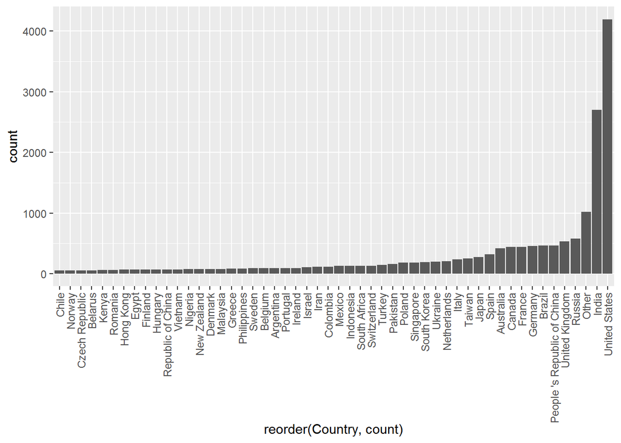

```r
residenceFilter <- residence %>%
  filter(count >= 20)

ggplot(residenceFilter, aes(x = reorder(Country, count), y = count)) +
  geom_bar(stat = "identity") +
  theme(axis.text.x = element_text(angle = 90,
                                   vjust = 0.5,
                                   hjust = 1))
```

### Age Analysis

```
##           Question
## 1 What's your age?
```

```r
# This column needs to be read as numbers
cleanPIData$Age <- as.numeric(cleanPIData$Age)

age <- chooseOne("Age") %>%
   # Remove values < 1 year
  filter(!Age < 1)
age
```

```
## # A tibble: 83 x 3
##      Age count percent
##    <dbl> <int>   <dbl>
##  1    25   964    5.89
##  2    24   895    5.47
##  3    26   885    5.41
##  4    27   840    5.14
##  5    23   838    5.12
##  6    30   776    4.74
##  7    28   759    4.64
##  8    29   731    4.47
##  9    22   693    4.24
## 10    31   597    3.65
## # ... with 73 more rows
```

What is the age distribution of users?

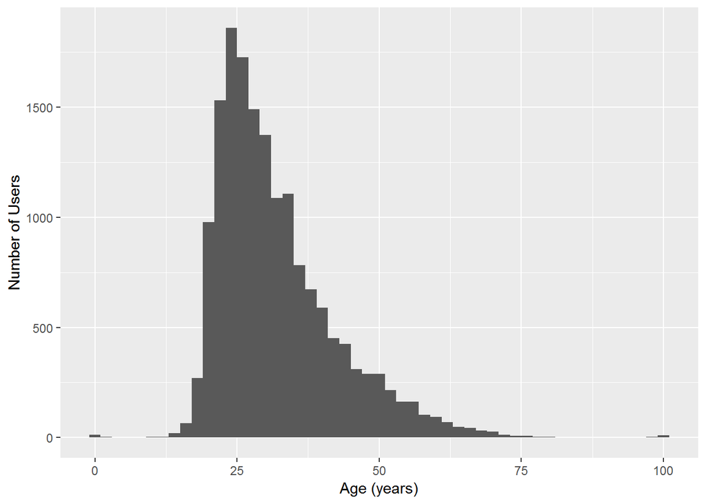

```r
agedata <- cleanPIData %>%
  # Remove any rows where the respondent didn't answer the question
  filter(!Age == "") %>%
  select(Age)


ggplot(agedata, aes(x = Age)) +
  geom_histogram(binwidth = 2) +
  xlab("Age (years)") +
  ylab("Number of Users")
```

The vast majority of Kaggle users are young adults (early 20’s to 30’s).

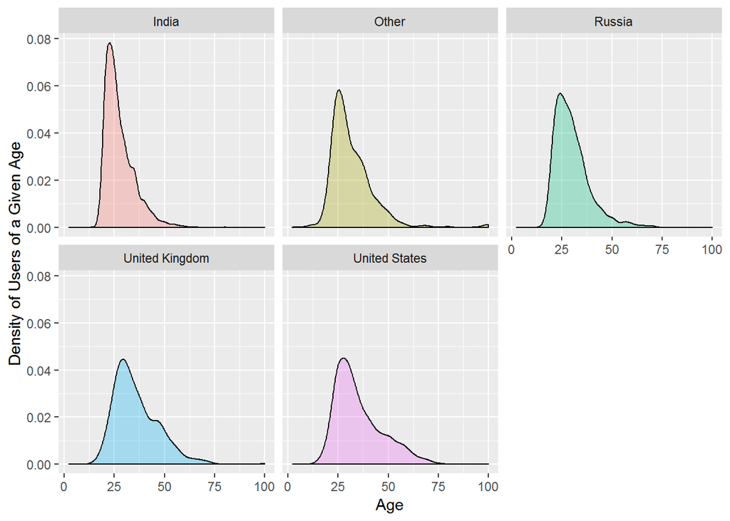

```r
top5 <- residence %>%
  # add a row number to each row

  mutate(row = row_number()) %>%
  # select only the top 5 countries
  filter( row <= 5) %>%
  # keep only the country name column
  select(Country) %>%
  # change these to character elements, instead of factors
  mutate(Country = as.character(Country))

# Create a list of the top 5 countries
top5List <- top5$Country

top5Age <- cleanPIData %>%
  # Keep only entries whose country is included in the top 5 list

  filter(Country %in% top5List) %>%
  # Remove any ages that are under a year or NA or blank
  filter(Age > 1,
         !is.na(Age)) %>%
  filter(!Age == "") %>%
  # Group the data by country and then age
  group_by(Country, Age)

ggplot(top5Age, aes(x = Age,fill = Country)) +
  geom_density(alpha = 0.3) +
  facet_wrap(~Country) +
  ylab("Density of Users of a Given Age") +
  theme(legend.position="none")
```

there’s a wider age-range of users in the US and UK.

### Employment Status

```
##                                 Question
## 1 What's your current employment status?
```

```
## # A tibble: 7 x 3
##   EmploymentStatus                                     count percent
##   <fct>                                                <int>   <dbl>
## 1 Employed full-time                                   10878  65.2
## 2 Not employed, but looking for work                    2106  12.6
## 3 Independent contractor, freelancer, or self-employed  1326   7.95
## 4 Not employed, and not looking for work                 923   5.53
## 5 Employed part-time                                     914   5.48
## 6 I prefer not to say                                    419   2.51
## 7 Retired                                                118   0.707
```

## Career Profile (Non-Workers)

### Student Status

```
##                                                               Question
## 1 Are you currently enrolled as a student at a degree granting school?
```

```
## # A tibble: 2 x 3
##   StudentStatus count percent
##   <fct>         <int>   <dbl>
## 1 Yes             979    76.6
## 2 No              299    23.4
```

76% are currently in degree-granting schools.

### Learning Data Science

```
##                                                                                   Question
## 1 Are you currently focused on learning data science skills either formally or informally?
```

```
## # A tibble: 3 x 3
##   LearningDataScience                                         count percent
##   <fct>                                                       <int>   <dbl>
## 1 Yes, I'm focused on learning mostly data science skills       799   62.3
## 2 Yes, but data science is a small part of what I'm focused ~   428   33.4
## 3 No, I am not focused on learning data science skills           55    4.29
```

## Career Profile (Workers)

### Job Tasks

```
##                                                                                                     Question
## 1 Do you write code to analyze data in your current job, freelance contracts, or most recent job if retired?
```

```
## # A tibble: 2 x 3
##   CodeWriter count percent
##   <fct>      <int>   <dbl>
## 1 Yes        10133    77.0
## 2 No          3028    23.0
```

So 77% of employed Kaggle users write code in their current job.

```
##                                                      Question
## 1 Are you actively looking to switch careers to data science?
```

```
## # A tibble: 2 x 3
##   CareerSwitcher count percent
##   <fct>          <int>   <dbl>
## 1 Yes             2121    70.5
## 2 No               886    29.5
```

70% of the employed Kaggle users that don’t currently write code in their job are planning to switch into a data science field.

### Job Titles

```r
questionText("CurrentJobTitleSelect")
```

```
##                                                                                                                            Question
## 1 Select the option that's most similar to your current job/professional title (or most recent title if retired). - Selected Choice
```

```r
chooseOne("CurrentJobTitleSelect")
```

```
## # A tibble: 16 x 3
##    CurrentJobTitleSelect                count percent
##    <fct>                                <int>   <dbl>
##  1 Data Scientist                        2430  20.6
##  2 Software Developer/Software Engineer  1758  14.9
##  3 Other                                 1230  10.4
##  4 Data Analyst                          1208  10.2
##  5 Scientist/Researcher                   977   8.27
##  6 Business Analyst                       793   6.72
##  7 Researcher                             619   5.24
##  8 Machine Learning Engineer              617   5.22
##  9 Engineer                               552   4.67
## 10 Programmer                             459   3.89
## 11 Computer Scientist                     335   2.84
## 12 Statistician                           288   2.44
## 13 DBA/Database Engineer                  186   1.58
## 14 Predictive Modeler                     181   1.53
## 15 Data Miner                             118   0.999
## 16 Operations Research Practitioner        58   0.491
```

About 45% of Kaggle users are either Data Scientists, Software Developers/Engineers or Data Analysts. Predictive Modeler, Data Miner, and Operations Research Practitioner are among the least common job titles.

### training in each category

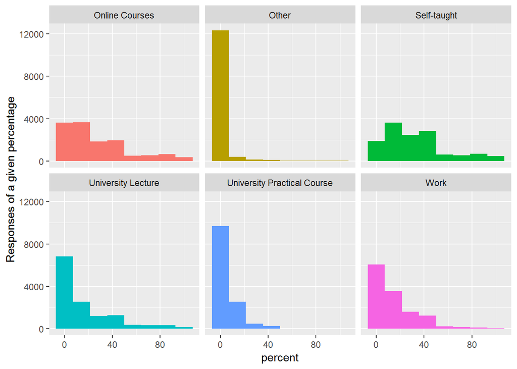

```r
training <- cleanPIData %>%
  # Keep only the columns that start with "LearningCategory" and don't include "FreeForm"
  select(starts_with("LearningCategory"), -contains("FreeForm")) %>%
  # Set column names
  purrr::set_names(c("Self-taught", "Online Courses", "Work", "University Lecture", "University Practical Course", "Other")) %>%
  # Re-structure the data
  gather(key = response, value = percent) %>%
  # Remove any rows where the percentage was NA
  filter(!is.na(percent)) %>%
  # Change the percentage column to a number
  mutate(percent = as.numeric(percent))

ggplot(training, aes(x = percent, fill = response)) +
  geom_histogram(bins = 8) +
  facet_wrap(~response) +
  ylab("Responses of a given percentage") +
  theme(legend.position="none")
```

Online courses and self-teaching seem to have the widest range of percentages reported.